[figure not shown]

## **Modelos Dinâmicos Lineares**

## *Douglas Braga*

```r
require(MASS)
require(dlm)
require(TeachingDemos)
require(purrr)

set.seed(21081996)
```

### Sumário

1) Modelo polinomial de primeira ordem

2) Modelo polinomial de segunda ordem ou modelo de crescimento linear

- 1 - Definição do modelo
- 2 - Simulando modelo

3) Aplicação nos dados do Nilo

4) Modelo com sazonalidade e tendência

5) Filtro de Kalman

6) Suavizador de Kalman

7) Fatores de desconto

8) Forward filtering backward sampling (FFBS)

### 1) Modelo polinomial de primeira ordem

#### 2 - Simulando modelo:

```r
gera = function(sigma_w,sigma_v,n=100){
  mi = c()
  mi[1] = 25

  yt = c()
  yt[1] = mi[1] + rnorm(1,0,sqrt(sigma_v))

  for(i in 1:n){
    mi[i+1] = mi[i] + rnorm(1,0,sigma_w)
    yt[i+1] = mi[i+1] + rnorm(1,0,sigma_v)
  }

  plot(yt,type = 'l',col=2,main=paste("tx ",as.character(sigma_w/sigma_v)))
  lines(mi,lty=3)
}
```

W/V pequeno: boa parte do movimento da série é devido as observações.

W/V grande: moveimentos devido ao sistema.

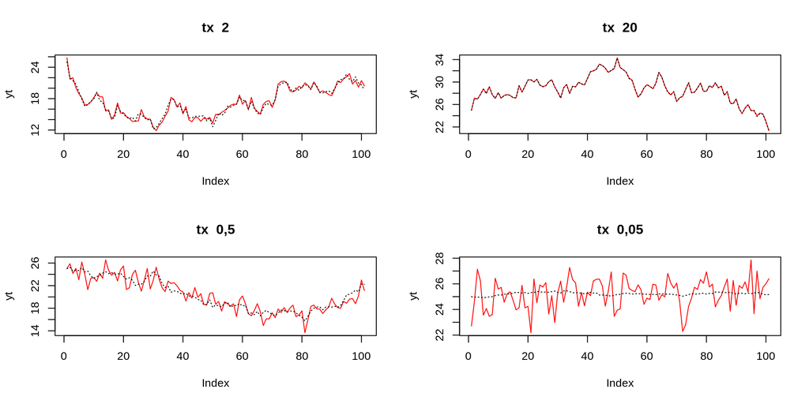

```r
par(mfrow=c(2,2))
gera(1,.5)
gera(1,.05)
gera(.5,1)
gera(.05,1)
```

#### 3 - Estimando os parâmetros

```r
W = .05
V = 1

gera = function(sigma_w,sigma_v,n=100){
  mi = c()
  mi[1] = 25

  yt = c()
  yt[1] = mi[1] + rnorm(1,0,sqrt(sigma_v))

  for(i in 1:n){
    mi[i+1] = mi[i] + rnorm(1,0,sigma_w)
    yt[i+1] = mi[i+1] + rnorm(1,0,sigma_v)
  }

  return(list(Y=yt,mu=mi))
}

dados = gera(W,V)
```

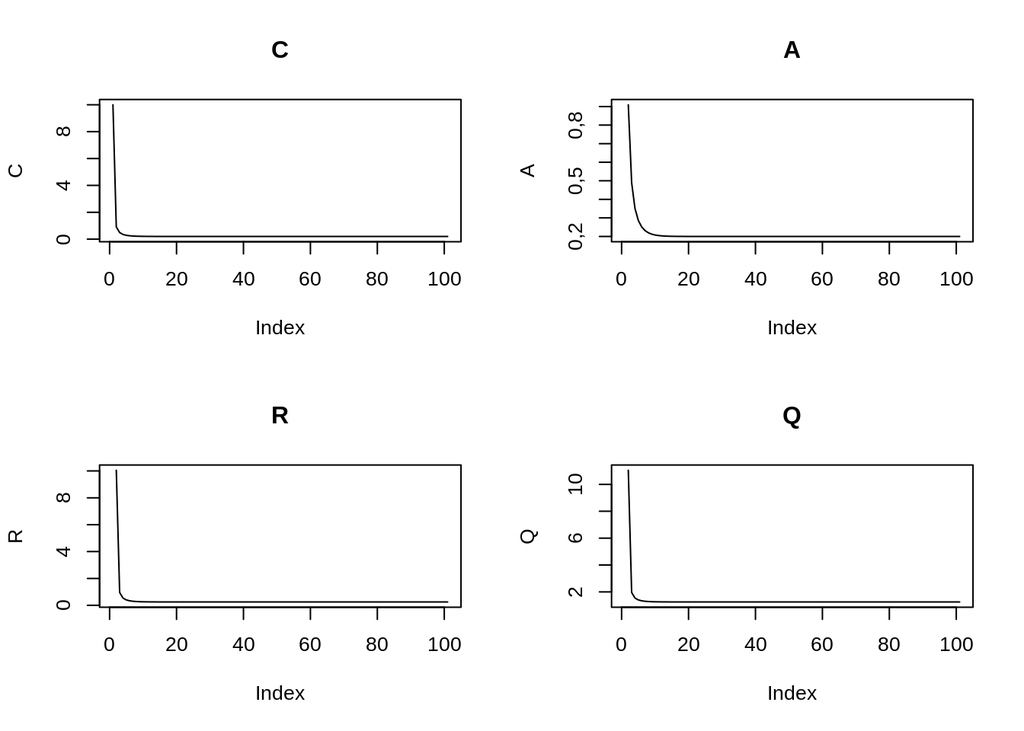

```r
m = c()
C = c()

m[1] = 0
C[1] = 10

a = c()
f = c()
A = c()
e = c()
R = c()
Q = c()

for(t in 2:101){
  a[t] = m[t-1]
  R[t] = C[t-1] + W
  f[t] = a[t]
  Q[t] = R[t]+V

  A[t] = R[t]/Q[t]
  e[t] = dados$Y[t] - f[t]
  m[t] = a[t] + A[t]*e[t]
  C[t] = A[t]*V
}


par(mfrow=c(1,1))
par(mfrow=c(2,2))
plot(C,main = "C",type="l")
plot(A,main = "A",type="l")
plot(R,main = "R",type="l")
plot(Q,main = "Q",type="l")
```

### 2) Modelo polinomial de segunda ordem ou modelo de crescimento linear

#### 1 - Definição do modelo:

$$y_t = F_t^{'}\theta_t+\nu_t, \mbox{ } \nu_t \mbox{~N(0,V}_t \mbox{)} \\
\theta_t = G_t\theta_{t-1}+w_t, \mbox{ } W_t \mbox{~N(0,}w_t \mbox{)} \\
\mbox{Onde } \theta_t = \begin{pmatrix} \mu_t \\ \beta_t \end{pmatrix} \\
\mbox{e } w_t = \begin{pmatrix} w_{t1} & 0 \\ 0 & w_{t2} \end{pmatrix}$$

#### 2 - Gerar serie

##### 1. Função geral para gerar séries (GERAR SÉRIES)

Agora será considerado o modelo matricial que é facilmente generalizado para os demais modelos.

```r
gera_dlm = function(qtd_obs = 100,Vt = NULL, Wt = NULL, Ft = NULL, Gt = NULL){

  qtd_tt = ifelse(length(Wt)>1,ncol(Wt),1)

  Yt = c()
  Tt = matrix(c(mvrnorm(1,rep(0,qtd_tt),Wt*100),rep(NA,(qtd_obs-1)*qtd_tt)),nrow = qtd_tt)

  Yt[1] = Ft %*% Tt[,1] + rnorm(1,0,Vt)

  for(i in 2:qtd_obs){
    Tt[,i] = Gt %*% Tt[,i-1] + ifelse(qtd_tt!=1,mvrnorm(1,rep(0,qtd_tt),Wt),rnorm(1,0,sqrt(Wt)))
    Yt[i] = Ft %*% Tt[,i] + rnorm(1,0,sqrt(Vt))
  }

  return(list(obs = Yt,
              param = Tt,
              Ft = Ft,
              Gt = Gt,
              Wt = Wt,
              Vt = Vt))
}
```

```r
Vt = 50 #variância observacional

cat("\n Matriz W \n")
```

```
##
##  Matriz W
```

```r
(Wt = matrix(c(5,0,0,2),nrow = 2)) #matriz de covariância dos parâmetros
```

```
##      [,1] [,2]
## [1,]    5    0
## [2,]    0    2
```

```r
cat("\n Vetor F \n")
```

```
##
##  Vetor F
```

```r
(Ft = c(1,0))
```

```
## [1] 1 0
```

```r
cat("\n Matriz G \n")
```

```
##
##  Matriz G
```

```r
(Gt = matrix(c(1,0,1,1),nrow = 2))
```

```
##      [,1] [,2]
## [1,]    1    1
## [2,]    0    1
```

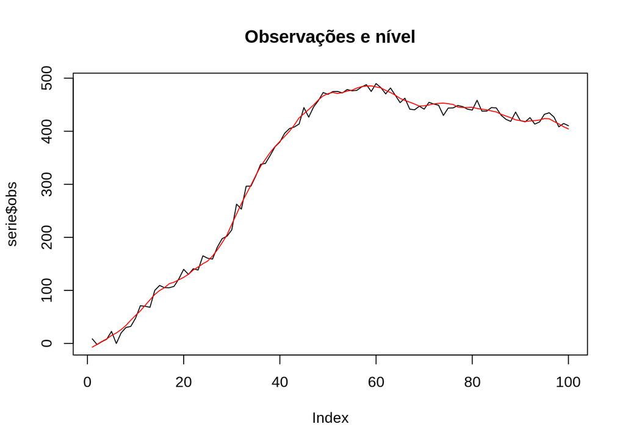

```r
serie = gera_dlm(Vt = Vt, Wt = Wt,Ft = Ft,Gt = Gt)

plot(serie$obs,type="l", main = "Observações e nível")
lines(serie$param[1,],col="red")
```

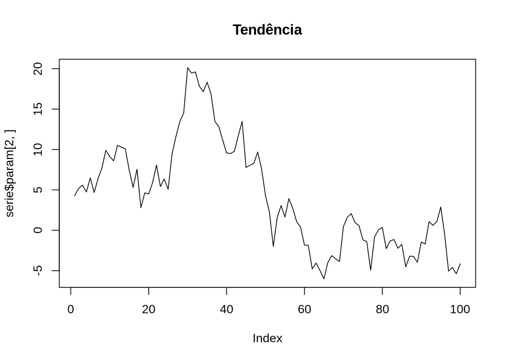

```r
plot(serie$param[2,],type="l",main = "Tendência")
```

#### 3 - Estimando os parâmetros

##### 1. Utilizando o pacote dlm

Criando objeto do modelo dinâmico

```r
MDL_2ordem <- dlm(FF = matrix(Ft,nrow=1),
                  V = Vt,
                  GG = Gt,
                  W = Wt,
                  m0 = rep(0, 2),
                  C0 = 10 * diag(2))
```

Utilizando filtro de Kalman

```r
filter <- dlmFilter(serie$obs,MDL_2ordem)

str(filter,1)
```

```
## List of 9
##  $ y  : num [1:100] 8,71 -2,14 3,35 7,92 22,70 ...
##  $ mod:List of 6
##   ..- attr(*, "class")= chr "dlm"
##  $ m  : num [1:101, 1:2] 0,00 2,90 1,10 2,31 5,50 ...
##  $ U.C:List of 101
##  $ D.C: num [1:101, 1:2] 3,16 2,52 2,27 2,19 2,17 ...
##  $ a  : num [1:100, 1:2] 0,00 4,06 1,14 2,73 6,75 ...
##  $ U.R:List of 100
##  $ D.R: num [1:100, 1:2] 5,52 7,29 7,95 7,92 7,74 ...
##  $ f  : num [1:100] 0,00 4,06 1,14 2,73 6,75 ...
##  - attr(*, "class")= chr "dlmFiltered"
```

##### 2. Utilizando comandos criados (FILTRO DE KALMAN)

```r
filt_kalman = function(serie,Ft,Gt,Wt,Vt){
  A=list()
  f=c()
  R=list()
  Q=c()
  a=list()
  e=c()
  #m=list()
  m = matrix(NA,nrow = ncol(Gt),ncol = length(serie))
  C=list()

  C0 = diag(ncol(Wt))
  W = Wt
  V = Vt

  a[[1]]=Gt%*%rep(0,ncol(Wt))
  f[1]=t(Ft)%*%a[[1]]
  R[[1]]=Gt%*%C0%*%t(Gt)+W
  Q[1]=t(Ft)%*%R[[1]]%*%Ft+V
  A[[1]]=R[[1]]%*%Ft*(Q[1])^(-1)
  e[1]=serie[1]-f[1]
  m[,1]=a[[1]]+A[[1]]*e[1]
  C[[1]]=R[[1]]-A[[1]]%*%t(A[[1]])*Q[1]

  for (i in 2:length(serie)){
   a[[i]]=Gt%*%m[,i-1]
   f[i]=t(Ft)%*%a[[i]]
   R[[i]]=Gt%*%C[[i-1]]%*%t(Gt)+W
   Q[i]=t(Ft)%*%R[[i]]%*%Ft+V
   A[[i]]=R[[i]]%*%Ft*(Q[i])^(-1)
   e[i]=serie[i]-f[i]
   m[,i]=a[[i]]+A[[i]]*e[i]
   C[[i]]=R[[i]]-A[[i]]%*%t(A[[i]])*Q[i]
  }
  f[length(serie)+1]=t(Ft)%*%a[[i]]

  return(list(Tt = m,
              a = a,
              R = R,
              f = f,
              Q = Q,
              C = C))
}
```

```r
kalman = filt_kalman(serie$obs,Ft,Gt,Wt,Vt)
```

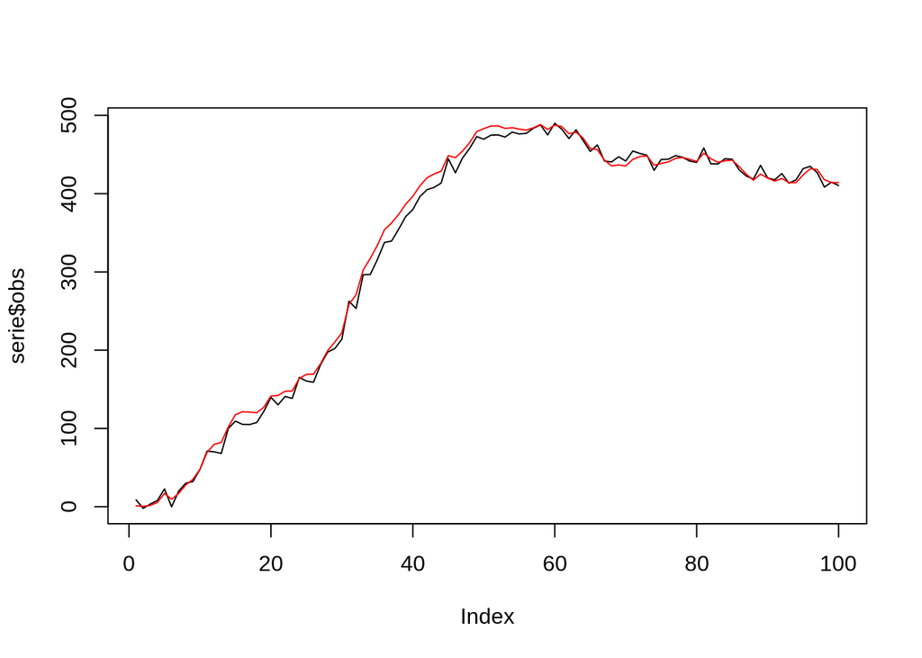

```r
plot(serie$obs,type = 'l')
lines(kalman$f[-1],col='red')
```

### 3) Aplicação nos dados do Nilo

```r
mod.nilo <- dlmModPoly(order = 1, dV = 15100, dW = 7550) #modelo

NileFilt2 <- dlmFilter(Nile, mod.nilo) #filtro de kalman
```

```r
int1_mu=c()
int2_mu=c()

int1_y=c()
int2_y=c()

for(i in 1:length(NileFilt2$f)){
  samp1 = rnorm(1000,NileFilt2$m[i+1],sqrt(dlmSvd2var(NileFilt2$U.C[[i+1]], NileFilt2$D.C[i+1,])))
  samp2 = rnorm(1000,NileFilt2$f[i],sqrt(dlmSvd2var(NileFilt2$U.R[[i]], NileFilt2$D.R[i])))

  int.hpd_mu = emp.hpd(samp1,.95)
  int1_mu[i] = int.hpd_mu[1]
  int2_mu[i] = int.hpd_mu[2]

  int.hpd_yt = emp.hpd(samp2,.95)
  int1_y[i] = int.hpd_yt[1]
  int2_y[i] = int.hpd_yt[2]
}
```

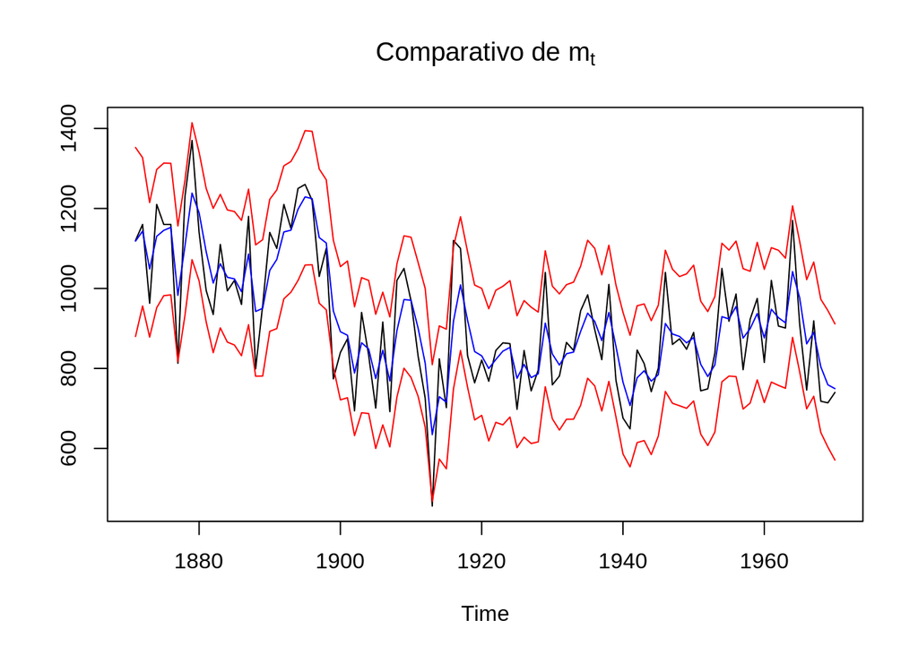

```r
ts.plot(Nile,
        dropFirst(NileFilt2$m),
        int1_mu,
        int2_mu,
        gpars = list(col = c("black","blue","red","red")),
        main = expression("Comparativo de"~m[t]))
```

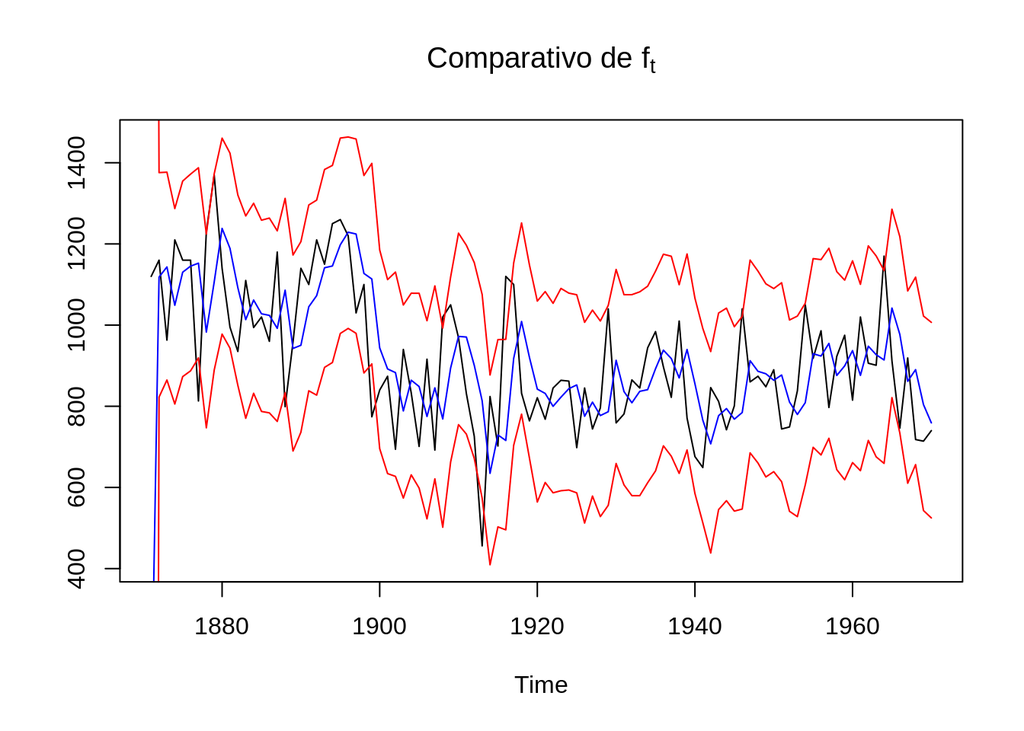

```r
ts.plot(Nile,
        NileFilt2$f,
        int1_y,
        int2_y,
        gpars = list(col = c("black","blue","red","red"),ylim=c(min(int1_y[-1]),max(int2_y[-1]))),
        main = expression("Comparativo de"~f[t]))
```

### 4) Modelo com sazonalidade e tendência

$$y_t = F'_t \beta_t + \nu_t$$

$$\beta_t = G_t\beta_{t-1} + \omega_t \\$$

$$onde,$$

$$\beta'_t = (\alpha_0 \mbox{ } \beta_{1,t} \mbox{ } \gamma_{1,t} \mbox{ } \beta_{2,t} \mbox{ } \gamma_{2,t} \mbox{ ... } \beta_{q-1,t} \mbox{ } \gamma_{q-1,t})$$

$$F'_t = \left\{\begin{array}{rc1}
\mbox{(1 1 0 1 0 ... 1 0), p ímpar;} \\
\mbox{(1 1 0 1 0 ... 1 0 1), p par.}
\end{array}\right.\\$$
Onde a matriz $G_t$ é uma matriz bloco diagonal.

$$G_t= \left\{\begin{array}{rc2}
diag(1,G_1,...,G_r,...,G_{q-1}),\mbox{p ímpar};\\
diag(1,G_1,...,G_r,...,G_{q-1},-1),\mbox{p par}
\end{array}\right.$$

```r
periodo = 12

rodadas = 12*5

omega = 2*pi/periodo
```

#### 1 - Um harmônico com nível

```r
r = 3

U = matrix(0,nrow = r, ncol = r)

for(i in 1:r){
  for(j in 1:r){
    if(i>j){U[i,j]=rnorm(1,0,sqrt(1))}
    if(i==j){U[i,j]=abs(rnorm(1,0,sqrt(1)))}
  }
}

(Wt = t(U) %*% U) #matriz de covariância dos parâmetros
```

```
##            [,1]        [,2]       [,3]
## [1,]  2,1055983 -1,81310743 0,45511937
## [2,] -1,8131074  2,77312406 0,02297047
## [3,]  0,4551194  0,02297047 0,29918585
```

```r
Vt = 200 #variância em yt

cat("\n Vetor F \n")
```

```
##
##  Vetor F
```

```r
(Ft = c(1,1,0))
```

```
## [1] 1 1 0
```

```r
cat("\n Matriz G \n")
```

```
##
##  Matriz G
```

```r
(Gt = matrix(c(1,0,0,0,cos(omega),-sin(omega),0,sin(omega),cos(omega)),nrow = 3))
```

```
##      [,1]       [,2]      [,3]
## [1,]    1  0,0000000 0,0000000
## [2,]    0  0,8660254 0,5000000
## [3,]    0 -0,5000000 0,8660254
```

```r
hamon.1 = gera_dlm(rodadas,Vt,Wt,Ft,Gt)
```

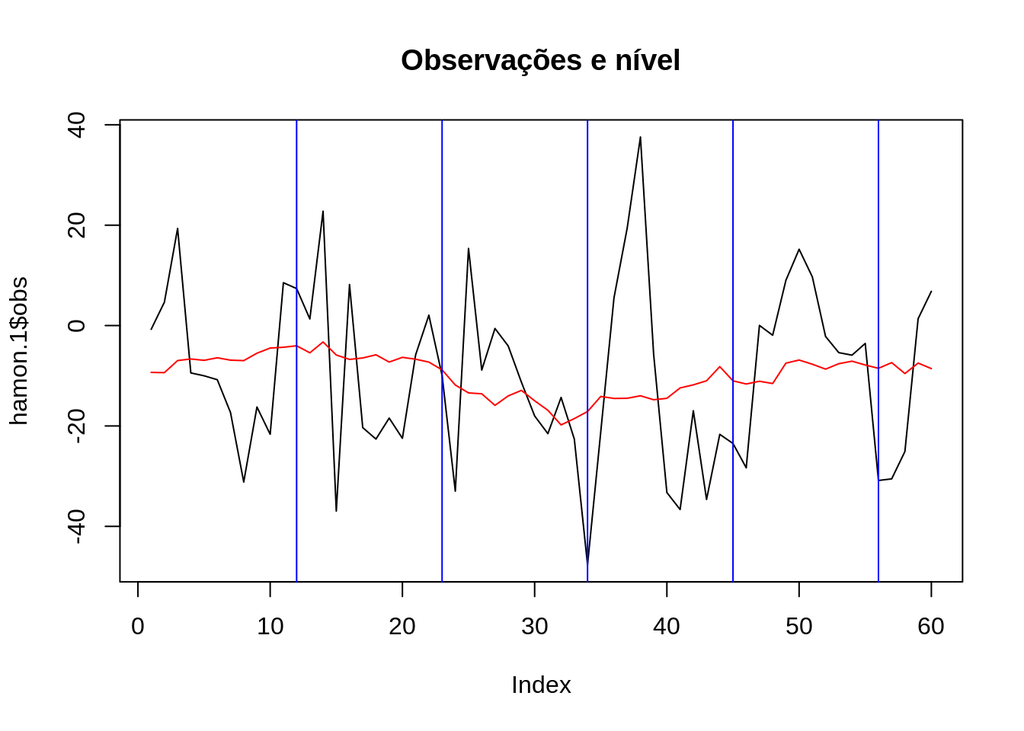

```r
amplitude = sqrt(hamon.1$param[2,]^2 + hamon.1$param[3,]^2)

plot(hamon.1$obs,type="l", main = "Observações e nível")
lines(hamon.1$param[1,],col="red")
for(i in seq(periodo,rodadas,periodo-1)){
  abline(v=i,col='blue')
}
```

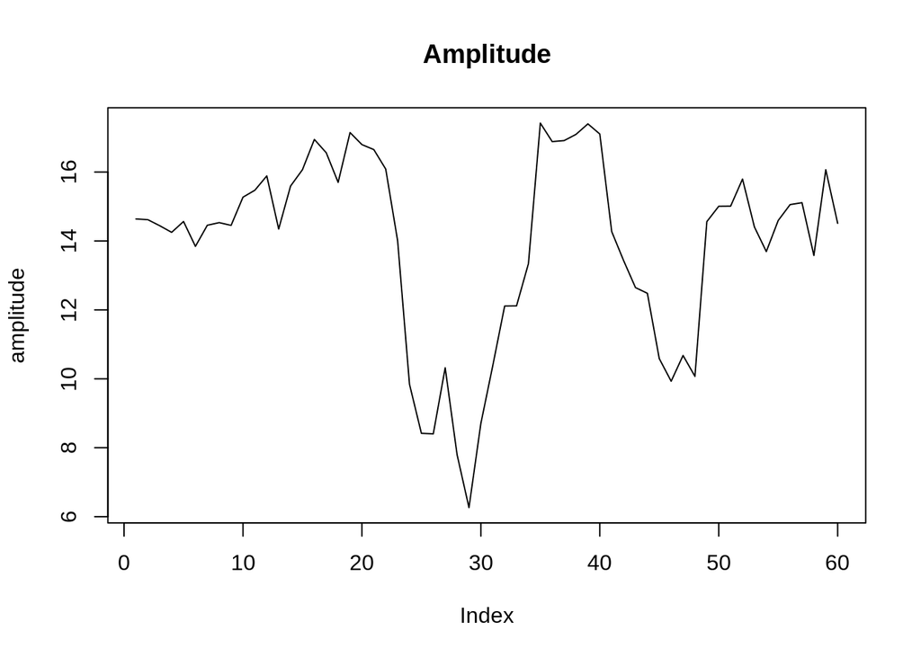

```r
plot(amplitude,type="l",main = "Amplitude")
```

#### 2 - Um harmônico com nível e tendência

```r
r = 4

U = matrix(0,nrow = r, ncol = r)

for(i in 1:r){
  for(j in 1:r){
    if(i>j){U[i,j]=rnorm(1,0,sqrt(1))}
    if(i==j){U[i,j]=abs(rnorm(1,0,sqrt(1)))}
  }
}

(Wt = t(U) %*% U) #matriz de covariância dos parâmetros
```

```
##            [,1]        [,2]        [,3]         [,4]
## [1,]  2,0071716 -2,03071062 -0,74684594 -0,049893100
## [2,] -2,0307106  6,25047770 -0,26981364 -0,012773130
## [3,] -0,7468459 -0,26981364  0,67847271  0,047302558
## [4,] -0,0498931 -0,01277313  0,04730256  0,003370367
```

```r
Vt = 50 #variância em yt

cat("\n Vetor F \n")
```

```
##
##  Vetor F
```

```r
(Ft = c(1,0,1,0))
```

```
## [1] 1 0 1 0
```

```r
cat("\n Matriz G \n")
```

```
##
##  Matriz G
```

```r
(Gt = matrix(c(1,0,0,0,1,1,0,0,0,0,cos(omega),-sin(omega),0,0,sin(omega),cos(omega)),nrow = 4))
```

```
##      [,1] [,2]       [,3]      [,4]
## [1,]    1    1  0,0000000 0,0000000
## [2,]    0    1  0,0000000 0,0000000
## [3,]    0    0  0,8660254 0,5000000
## [4,]    0    0 -0,5000000 0,8660254
```

```r
hamon.2 = gera_dlm(rodadas,Vt,Wt,Ft,Gt)
```

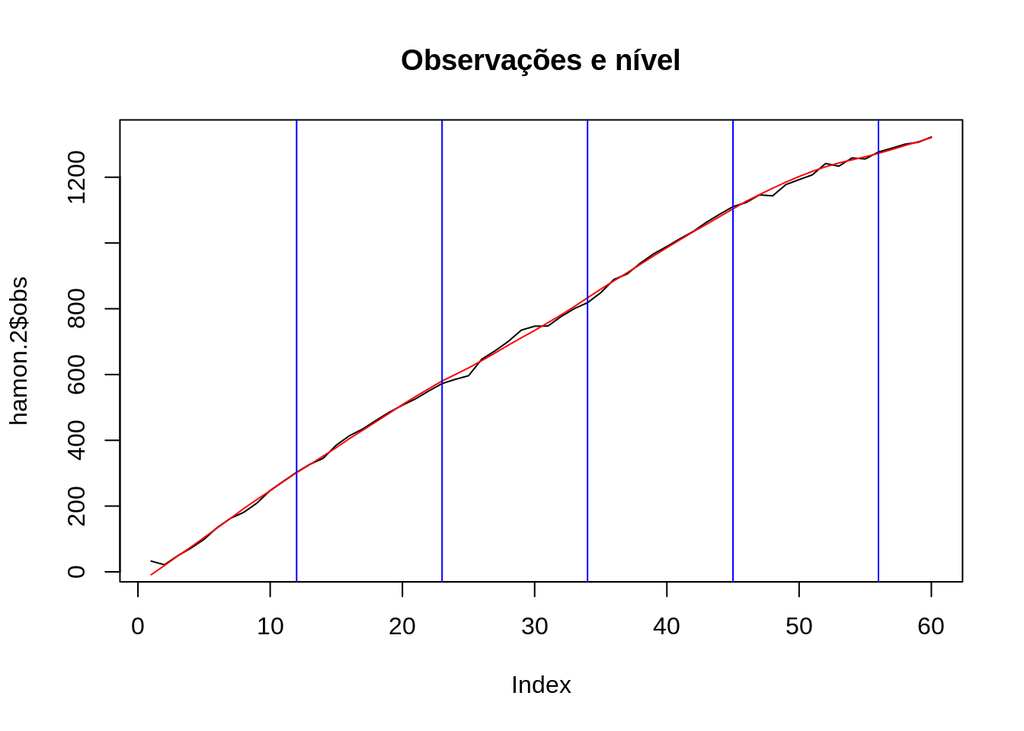

```r
amplitude = sqrt(hamon.2$param[3,]^2 + hamon.2$param[4,]^2)

plot(hamon.2$obs,type="l", main = "Observações e nível")
lines(hamon.2$param[1,],col="red")
for(i in seq(periodo,rodadas,periodo-1)){
  abline(v=i,col='blue')
}
```

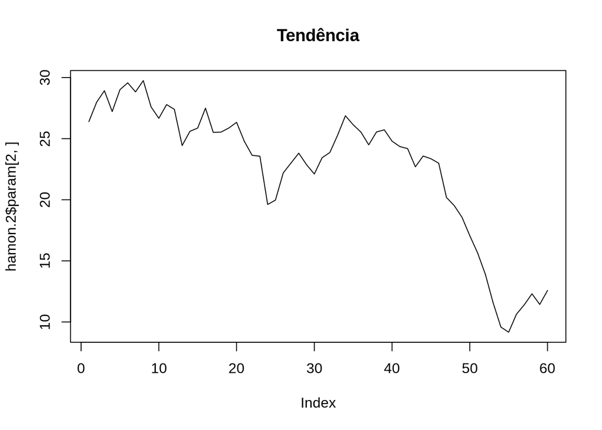

```r
plot(hamon.2$param[2,],type="l",main = "Tendência")
```

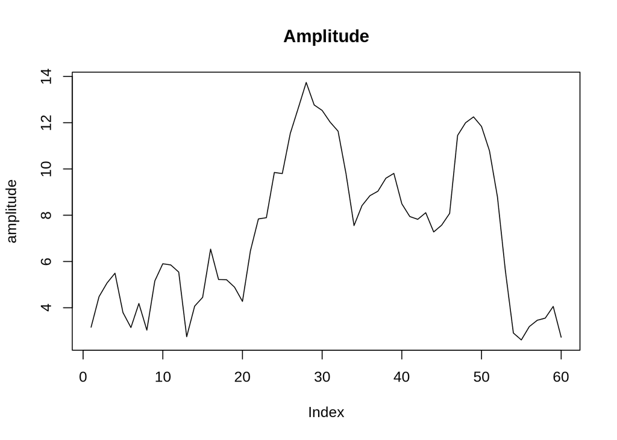

```r
plot(amplitude,type="l",main = "Amplitude")
```

#### 3 - Dois harmônicos com nível

```r
r = 5

U = matrix(0,nrow = r, ncol = r)

for(i in 1:r){
  for(j in 1:r){
    if(i>j){U[i,j]=rnorm(1,0,sqrt(1))}
    if(i==j){U[i,j]=abs(rnorm(1,0,sqrt(1)))}
  }
}

(Wt = t(U) %*% U)
```

```
##            [,1]      [,2]        [,3]       [,4]        [,5]
## [1,] 3,08058232 1,3340395  0,02961465  0,4831367  0,03368189
## [2,] 1,33403947 5,6655143  1,41901864  1,3439444  0,13608288
## [3,] 0,02961465 1,4190186  1,19390571 -0,1185760 -0,08633449
## [4,] 0,48313673 1,3439444 -0,11857595  5,9982919  0,98375066
## [5,] 0,03368189 0,1360829 -0,08633449  0,9837507  0,16816152
```

```r
cat("\n Vetor F \n")
```

```
##
##  Vetor F
```

```r
(Ft = c(1,1,0,1,0))
```

```
## [1] 1 1 0 1 0
```

```r
cat("\n Matriz G \n")
```

```
##
##  Matriz G
```

```r
(Gt = matrix(c(1,0,0,0,0,
               0,cos(omega),-sin(omega),0,0,
               0,sin(omega),cos(omega),0,0,
               0,0,0,cos(2*omega),-sin(2*omega),
               0,0,0,sin(2*omega),cos(2*omega)
             ),nrow = 5))
```

```
##      [,1]       [,2]      [,3]       [,4]      [,5]
## [1,]    1  0,0000000 0,0000000  0,0000000 0,0000000
## [2,]    0  0,8660254 0,5000000  0,0000000 0,0000000
## [3,]    0 -0,5000000 0,8660254  0,0000000 0,0000000
## [4,]    0  0,0000000 0,0000000  0,5000000 0,8660254
## [5,]    0  0,0000000 0,0000000 -0,8660254 0,5000000
```

```r
hamon.3 = gera_dlm(rodadas,Vt,Wt,Ft,Gt)
```

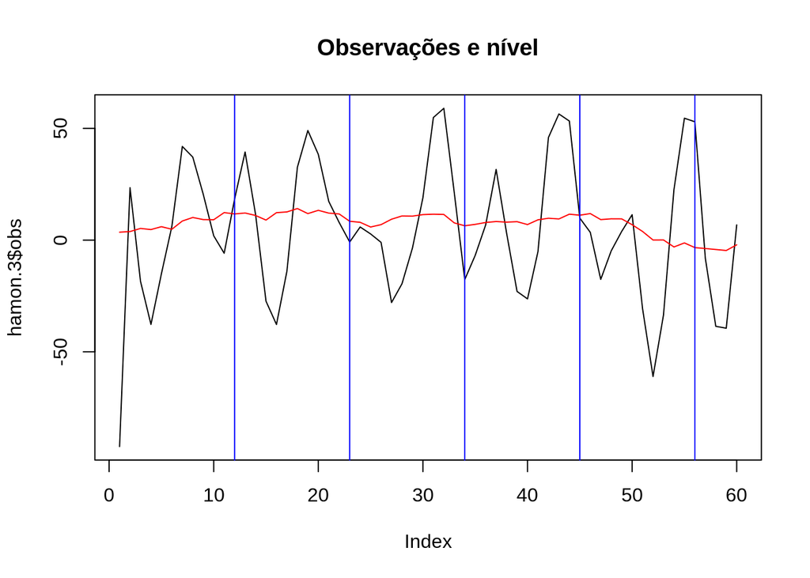

```r
amplitude1 = sqrt(hamon.3$param[2,]^2 + hamon.3$param[3,]^2)
amplitude2 = sqrt(hamon.3$param[4,]^2 + hamon.3$param[5,]^2)

plot(hamon.3$obs,type="l", main = "Observações e nível")
lines(hamon.3$param[1,],col="red")
for(i in seq(periodo,rodadas,periodo-1)){
  abline(v=i,col='blue')
}
```

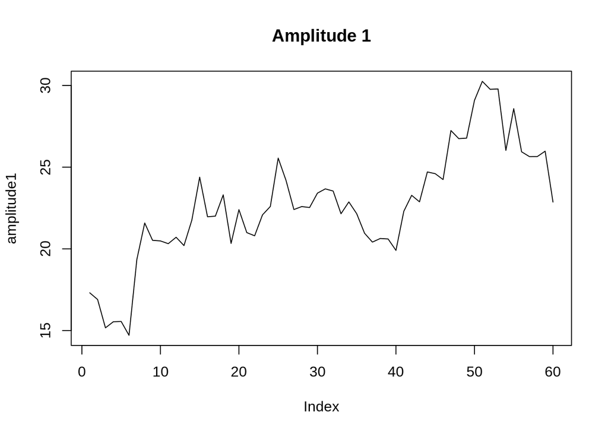

```r
plot(amplitude1,type="l",main = "Amplitude 1")
```

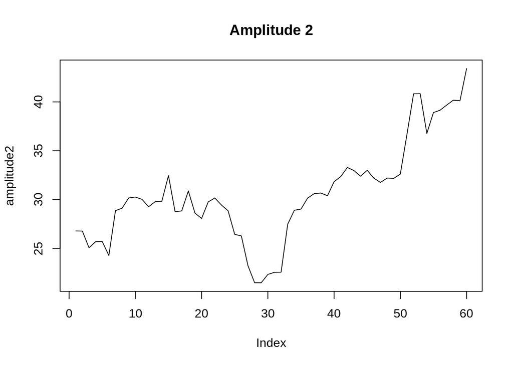

```r
plot(amplitude2,type="l",main = "Amplitude 2")
```

#### 4 - Nível, tendência, sazonalidade e covariável

$$y_t = F'_t\theta_t+x_t\alpha_t + \nu_t$$

$$\theta_t = G_t\theta_{t-1}+\omega_{1t}$$

$$\alpha_t = \alpha_{t-1} + \omega_{2t}$$

$$onde,$$

$$\theta_t = \begin{pmatrix}
\mu_t\\
\beta_t\\
\gamma_{1,t}\\
\gamma_{2,t}\\
\alpha_t
\end{pmatrix}$$

$$F'_t = \begin{pmatrix}
1 \mbox{ } 0 \mbox{ } 1 \mbox{ } 0 \mbox{ } x_t
\end{pmatrix}$$

$$\begin{align*}
G_t = \begin{pmatrix}
1 & 1 & 0 & 0 & 0 \\
0 & 1 & 0 & 0 & 0 \\
0 & 0 & cos & sen & 0 \\
0 & 0 & -sen & cos & 0 \\
0 & 0 & 0 & 0 & 1
\end{pmatrix}
\end{align*}$$

#### 5 - Modelo com sazonalidade, tendência e nível

##### 1. Gerando Série

```r
r = 4

U = matrix(0,nrow = r, ncol = r)

for(i in 1:r){
  for(j in 1:r){
    if(i>j){U[i,j]=rnorm(1,0,sqrt(1))}
    if(i==j){U[i,j]=abs(rnorm(1,0,sqrt(1)))}
  }
}

(Wt = t(U) %*% U)
```

```
##            [,1]       [,2]       [,3]       [,4]
## [1,]  8,8138888 -1,7857608  0,9140642 -3,5622416
## [2,] -1,7857608  1,0832909 -0,2718486  1,1223432
## [3,]  0,9140642 -0,2718486  0,1160610 -0,4839952
## [4,] -3,5622416  1,1223432 -0,4839952  2,0688339
```

```r
Vt = 20

cat("\n Vetor F \n")
```

```
##
##  Vetor F
```

```r
(Ft = c(1,0,1,0))
```

```
## [1] 1 0 1 0
```

```r
cat("\n Matriz G \n")
```

```
##
##  Matriz G
```

```r
(Gt = matrix(c(1,0,0,0,1,1,0,0,0,0,cos(omega),-sin(omega),0,0,sin(omega),cos(omega)),nrow = 4))
```

```
##      [,1] [,2]       [,3]      [,4]
## [1,]    1    1  0,0000000 0,0000000
## [2,]    0    1  0,0000000 0,0000000
## [3,]    0    0  0,8660254 0,5000000
## [4,]    0    0 -0,5000000 0,8660254
```

```r
hamon.4 = gera_dlm(rodadas,Vt,Wt,Ft,Gt)
```

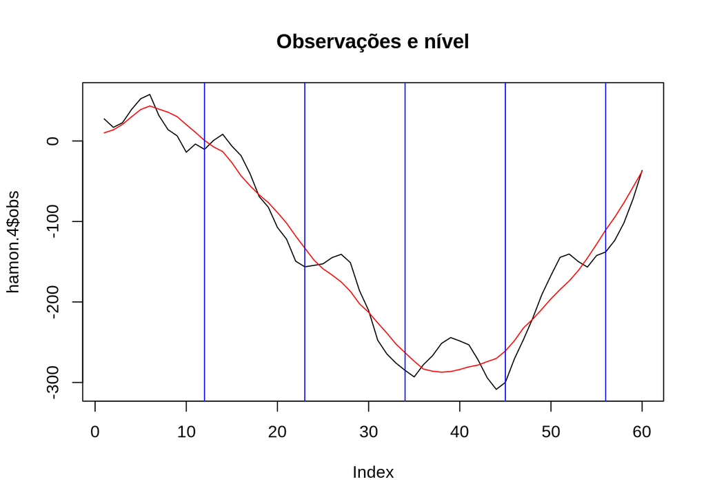

```r
amplitude = sqrt(hamon.4$param[3,]^2 + hamon.4$param[4,]^2)

plot(hamon.4$obs,type="l", main = "Observações e nível")
lines(hamon.4$param[1,],col="red")
for(i in seq(periodo,rodadas,periodo-1)){
  abline(v=i,col='blue')
}
```

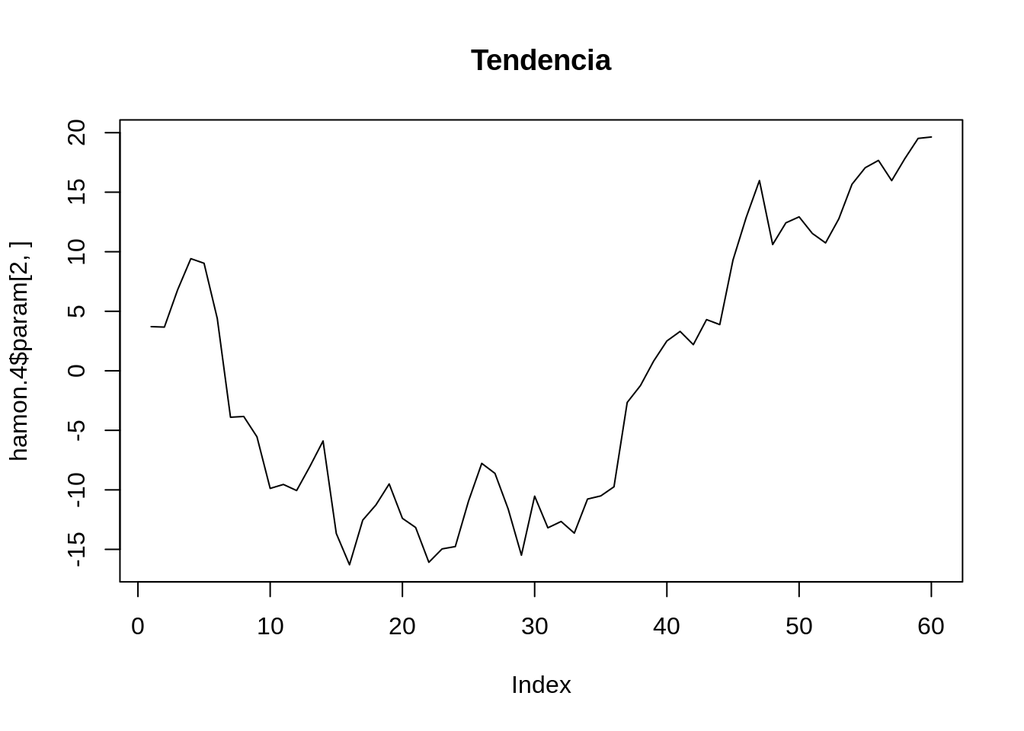

```r
plot(hamon.4$param[2,],type="l", main = "Tendencia")
```

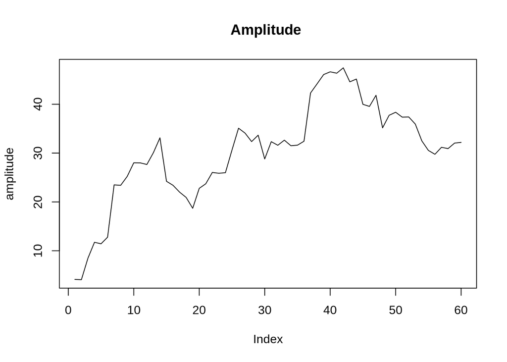

```r
plot(amplitude,type="l",main = "Amplitude ")
```

### 5) Filtro de Kalman

#### 1. Intervalo de credibilidade HPD (IC HPD)

```r
hpd.dlm = function(kalman, conf = .95 ,qtd.amostra = 1000){
  rodadas = length(kalman$f)-1
  nivel.pont = c()

  int1_mu=c()
  int2_mu=c()

  int1_y=c()
  int2_y=c()

  for(i in 1:rodadas){
    nivel.pont = c(nivel.pont,kalman$Tt[[i]][1])
    samp1 = rnorm(qtd.amostra,kalman$Tt[[i]][1],sqrt(kalman$C[[i]][1,1]))
    samp2 = rnorm(qtd.amostra,kalman$f[i+1],sqrt(kalman$Q[i]))

    int.hpd_mu = emp.hpd(samp1,.95)
    int1_mu[i] = int.hpd_mu[1]
    int2_mu[i] = int.hpd_mu[2]

    int.hpd_yt = emp.hpd(samp2,.95)
    int1_y[i] = int.hpd_yt[1]
    int2_y[i] = int.hpd_yt[2]
  }

  return(list(nivel.inf = int1_mu,
              nivel.pont = nivel.pont,
              nivel.sup = int2_mu,
              prev.inf = int1_y,
              prev.sup = int2_y))
}
```

#### 2. Matriz F e G corretas

```r
hamon.4$Ft
```

```
## [1] 1 0 1 0
```

```r
hamon.4$Gt
```

```
##      [,1] [,2]       [,3]      [,4]
## [1,]    1    1  0,0000000 0,0000000
## [2,]    0    1  0,0000000 0,0000000
## [3,]    0    0  0,8660254 0,5000000
## [4,]    0    0 -0,5000000 0,8660254
```

```r
hamon.4$Wt
```

```
##            [,1]       [,2]       [,3]       [,4]
## [1,]  8,8138888 -1,7857608  0,9140642 -3,5622416
## [2,] -1,7857608  1,0832909 -0,2718486  1,1223432
## [3,]  0,9140642 -0,2718486  0,1160610 -0,4839952
## [4,] -3,5622416  1,1223432 -0,4839952  2,0688339
```

```r
hamon.4$Vt
```

```
## [1] 20
```

```r
kalman = filt_kalman(hamon.4$obs,hamon.4$Ft,hamon.4$Gt,hamon.4$Wt,hamon.4$Vt)
```

```r
hpd = hpd.dlm(kalman)
```

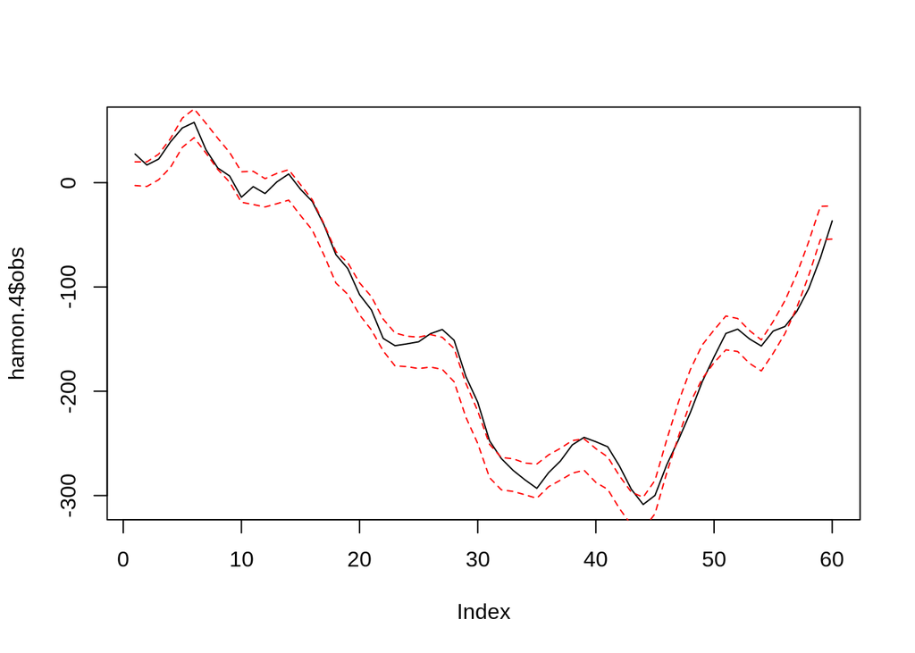

```r
plot(hamon.4$obs,type = 'l')
lines(hpd$prev.inf,col="red",lty=2)
lines(hpd$prev.sup,col="red",lty=2)
```

#### 3. Matriz F e G definidas erroneamente

Apenas com nível e tendência

```r
(Ft = hamon.4$Ft[1:2])
```

```
## [1] 1 0
```

```r
(Gt = hamon.4$Gt[1:2,1:2])
```

```
##      [,1] [,2]
## [1,]    1    1
## [2,]    0    1
```

```r
(Wt = hamon.4$Wt[1:2,1:2])
```

```
##           [,1]      [,2]
## [1,]  8,813889 -1,785761
## [2,] -1,785761  1,083291
```

```r
kalman = filt_kalman(hamon.4$obs,Ft,Gt,Wt,Vt)
```

```r
hpd = hpd.dlm(kalman)
```

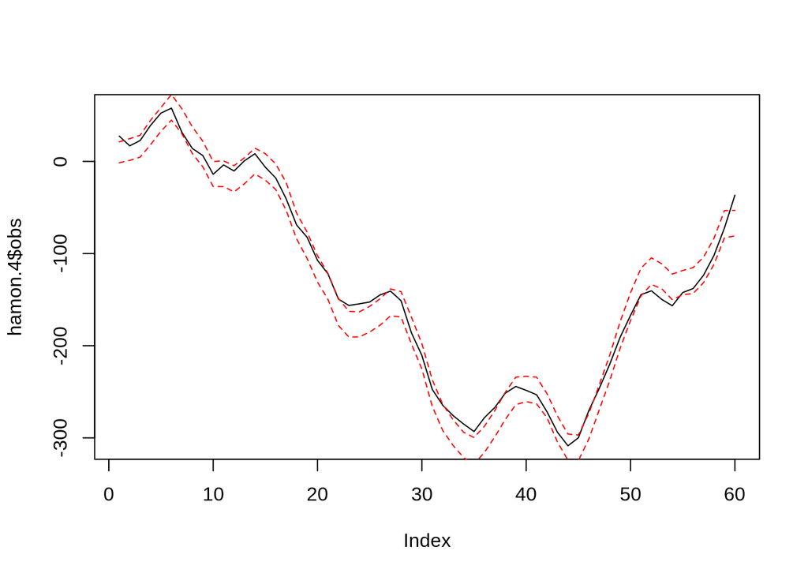

```r
plot(hamon.4$obs,type = 'l')
lines(hpd$prev.inf,col="red",lty=2)
lines(hpd$prev.sup,col="red",lty=2)
```

### 6) Suavizador de Kalman

```r
suavizador = function(filtro_kalman = NULL){
  rodadas = ncol(filtro_kalman$Tt)

  m.s = filtro_kalman$Tt
  c.s = filtro_kalman$C

  for(t in (rodadas-1):1){
    Bt = filtro_kalman$C[[t]] %*% t(Gt) %*% solve(filtro_kalman$R[[t+1]])
    m.s[,t] = filtro_kalman$Tt[,t] + (Bt %*% (m.s[,t+1] - filtro_kalman$a[[t+1]]))
    c.s[[t]] = filtro_kalman$C[[t]] - Bt %*% (filtro_kalman$R[[t+1]] - c.s[[t+1]]) %*% t(Bt)
  }

  return(list(Tt.s = m.s,
              C.s = c.s))
}

kalman.suavizado = suavizador(kalman)
```

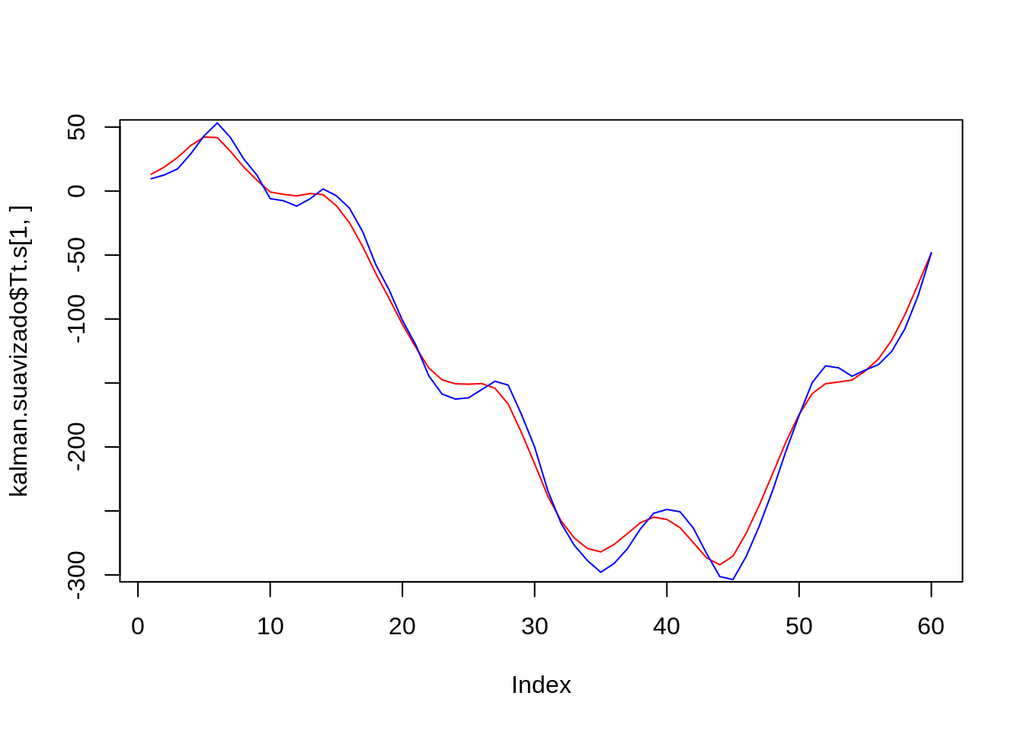

```r
plot(kalman.suavizado$Tt.s[1,],type = "l",col="red")
lines(kalman$Tt[1,],col="blue")
```

### 7) Fatores de desconto

#### 1 - Matriz Wt desconhecida (FILTRO DE KALMAN)

A matriz Wt é a informação sobre a variância e covariância dos fatores

Gerando série com nível e sazonalidade

```r
r = 5

U = matrix(0,nrow = r, ncol = r)

for(i in 1:r){
  for(j in 1:r){
    if(i>j){U[i,j]=rnorm(1,0,sqrt(1))}
    if(i==j){U[i,j]=abs(rnorm(1,0,sqrt(1)))}
  }
}

(Wt = t(U) %*% U)
```

```
##             [,1]        [,2]        [,3]        [,4]       [,5]
## [1,]  3,75872705 -0,28970493 -0,09841597  0,07336931  0,6885814
## [2,] -0,28970493  4,19386254 -0,39092500 -0,02812985 -0,1182971
## [3,] -0,09841597 -0,39092500  0,76124286  0,04097689  0,2806085
## [4,]  0,07336931 -0,02812985  0,04097689  0,02349320  0,2157692
## [5,]  0,68858140 -0,11829709  0,28060852  0,21576921  1,9996483
```

```r
cat("\n Vetor F \n")
```

```
##
##  Vetor F
```

```r
(Ft = c(1,1,0,1,0))
```

```
## [1] 1 1 0 1 0
```

```r
cat("\n Matriz G \n")
```

```
##
##  Matriz G
```

```r
(Gt = matrix(c(1,0,0,0,0,
               0,cos(omega),-sin(omega),0,0,
               0,sin(omega),cos(omega),0,0,
               0,0,0,cos(2*omega),-sin(2*omega),
               0,0,0,sin(2*omega),cos(2*omega)
             ),nrow = 5))
```

```
##      [,1]       [,2]      [,3]       [,4]      [,5]
## [1,]    1  0,0000000 0,0000000  0,0000000 0,0000000
## [2,]    0  0,8660254 0,5000000  0,0000000 0,0000000
## [3,]    0 -0,5000000 0,8660254  0,0000000 0,0000000
## [4,]    0  0,0000000 0,0000000  0,5000000 0,8660254
## [5,]    0  0,0000000 0,0000000 -0,8660254 0,5000000
```

```r
serie = gera_dlm(Vt = Vt, Wt = Wt,Ft = Ft,Gt = Gt)
```

```r
kalman = function(serie=NULL,Ft=NULL,Gt=NULL,Wt=NULL,Vt=NULL,f.desconto=1){
  if(f.desconto >= 1 & is.null(Wt)){stop("Falta fator de desconto ou matriz de covariância")}

  A=list()
  f=c()
  R=list()
  Q=c()
  a=list()
  e=c()
  m = matrix(NA,nrow = ncol(Gt),ncol = length(serie))
  C=list()

  C0 = diag(ncol(Gt))*sample(1:10,ncol(Gt))
  V = Vt

  a[[1]]=Gt%*%rep(0,ncol(Gt))
  f[1]=t(Ft)%*%a[[1]]

  if(f.desconto != 1 & is.null(Wt)){
    R[[1]]=(Gt%*%C0%*%t(Gt))/f.desconto
  }else {R[[1]]=(Gt%*%C0%*%t(Gt) + Wt)}

  Q[1]=t(Ft)%*%R[[1]]%*%Ft+V
  A[[1]]=R[[1]]%*%Ft*(Q[1])^(-1)
  e[1]=serie[1]-f[1]
  m[,1]=a[[1]]+A[[1]]*e[1]
  C[[1]]=R[[1]]-A[[1]]%*%t(A[[1]])*Q[1]

  for (i in 2:length(serie)){
   a[[i]]=Gt%*%m[,i-1]
   f[i]=t(Ft)%*%a[[i]]

   if(f.desconto != 1 & is.null(Wt)){
    R[[i]]=(Gt%*%C[[i-1]]%*%t(Gt))/f.desconto
   }else {R[[i]]=(Gt%*%C[[i-1]]%*%t(Gt) + Wt)}

   Q[i]=t(Ft)%*%R[[i]]%*%Ft+V
   A[[i]]=R[[i]]%*%Ft*(Q[i])^(-1)
   e[i]=serie[i]-f[i]
   m[,i]=a[[i]]+A[[i]]*e[i]
   C[[i]]=R[[i]]-A[[i]]%*%t(A[[i]])*Q[i]
  }
  #f[length(serie)+1]=t(Ft)%*%a[[i]]

  return(list(Tt = m,
              f = f,
              Q = Q,
              C = C,
              a = a,
              R = R))
}
```

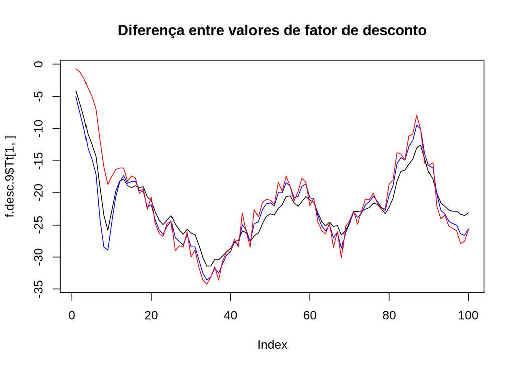

```r
f.desc.9 = kalman(serie = serie$obs,Ft = Ft,Gt = Gt,Vt = Vt,f.desconto = .9)

f.desc.7 = kalman(serie = serie$obs,Ft = Ft,Gt = Gt,Vt = Vt,f.desconto = .8)

f.desc.5 = kalman(serie = serie$obs,Ft = Ft,Gt = Gt,Vt = Vt,f.desconto = .7)

plot(f.desc.9$Tt[1,],type = 'l',
     ylim = c(min(f.desc.9$Tt[1,],f.desc.7$Tt[1,],f.desc.5$Tt[1,]),
              max(f.desc.9$Tt[1,],f.desc.7$Tt[1,],f.desc.5$Tt[1,])),
     main = "Diferença entre valores de fator de desconto")
lines(f.desc.7$Tt[1,],col = "blue")
lines(f.desc.5$Tt[1,],col = "red")
```

Pode-se notar que quanto maior o fator de desconto menos errático será a série, mais informação é utilizada do tempo anterior

#### 2 - Vt desconhecida (FILTRO DE KALMAN)

Lembrando que Vt é a variância observacional.

```r
kalman = function(serie=NULL,Ft=NULL,Gt=NULL,Wt=NULL,Vt=NULL,f.desconto=NULL,nt=1,dt=1){
  if(is.null(serie)|is.null(Ft)|is.null(Gt)){stop("Falta parâmetros")}
  if(is.null(f.desconto) & is.null(Wt)){stop("Falta fator de desconto ou matriz de covariância dos parâmetros")}

  A=list()
  f=c()
  R=list()
  Q=c()
  a=list()
  e=c()

  N = ifelse(length(Gt)==1,1,ncol(Gt))

  m = matrix(NA,nrow = N,ncol = length(serie))
  C=list()

  C0 = diag(N)*sample(1:10,N)

  if(is.null(Vt)){
    st = dt/nt

    R_star = list()
    Q_star = c()
    C_star = list()

    a[[1]]=Gt%*%rep(0,N)
    f[1]=t(Ft)%*%a[[1]]

    if(!is.null(f.desconto) & is.null(Wt)){
        R_star[[1]]=(Gt%*%C0%*%t(Gt))/f.desconto
    }else {R_star[[1]]=(Gt%*%C0%*%t(Gt) + Wt)}

    Q_star[1] = (1 + t(Ft)%*%R_star[[1]]%*%Ft)

    A[[1]]=R_star[[1]]%*%Ft*(Q_star[1])^(-1)
    e[1]=serie[1]-f[1]
    m[,1]=a[[1]]+A[[1]]*e[1]

    C_star[[1]]=(R_star[[1]]-A[[1]]%*%t(A[[1]])*Q_star[1])

    C[[1]] = st*C_star[[1]]
    R[[1]] = st*R_star[[1]]
    Q[[1]] = st*Q_star[[1]]

    for (i in 2:length(serie)){
        a[[i]]=Gt%*%m[,i-1]
        f[i]=t(Ft)%*%a[[i]]

        if(!is.null(f.desconto) & is.null(Wt)){
            R_star[[i]]=(Gt%*%C_star[[i-1]]%*%t(Gt))/f.desconto
        }else {R_star[[i]]=(Gt%*%C_star[[i-1]]%*%t(Gt) + Wt)}

        Q_star[i]=t(Ft)%*%R_star[[i]]%*%Ft+1
        A[[i]]=R_star[[i]]%*%Ft*(Q_star[i])^(-1)
        e[i]=serie[i]-f[i]
        m[,i]=a[[i]]+A[[i]]*e[i]
        C_star[[i]]=(R_star[[i]]-A[[i]]%*%t(A[[i]])*Q_star[i])

        C[[i]] = st[i-1]*C_star[[i]]
        R[[i]] = st[i-1]*R_star[[i]]
        Q[[i]] = st[i-1]*Q_star[[i]]

        nt = c(nt,nt[i-1]+1)
        dt = c(dt,dt[i-1]+st[i-1]*e[i]/Q[i])
        st = c(st,dt[i]/nt[i])
    }

    acc = list(MAE = sum(abs(e))/N,
               MSE = sum(e^2)/N,
               MAPE = sum(abs(e)/serie)/N)

    return(list(Tt = m,
                f = f,
                Q = Q,
                C = C,
                a = a,
                R = R,
                nt = nt,
                dt = dt,
                st = st,
                acc = acc))
  }else{
    a[[1]]=Gt%*%rep(0,N)
    f[1]=t(Ft)%*%a[[1]]

    if(!is.null(f.desconto) & is.null(Wt)){
      R[[1]]=(Gt%*%C0%*%t(Gt))/f.desconto
    }else {R[[1]]=(Gt%*%C0%*%t(Gt) + Wt)}

    Q[1]=t(Ft)%*%R[[1]]%*%Ft+V
    A[[1]]=R[[1]]%*%Ft*(Q[1])^(-1)
    e[1]=serie[1]-f[1]
    m[,1]=a[[1]]+A[[1]]*e[1]
    C[[1]]=R[[1]]-A[[1]]%*%t(A[[1]])*Q[1]

    for (i in 2:length(serie)){
     a[[i]]=Gt%*%m[,i-1]
     f[i]=t(Ft)%*%a[[i]]

     if(!is.null(f.desconto) & is.null(Wt)){
      R[[i]]=(Gt%*%C[[i-1]]%*%t(Gt))/f.desconto
     }else {R[[i]]=(Gt%*%C[[i-1]]%*%t(Gt) + Wt)}

     Q[i]=t(Ft)%*%R[[i]]%*%Ft+V
     A[[i]]=R[[i]]%*%Ft*(Q[i])^(-1)
     e[i]=serie[i]-f[i]
     m[,i]=a[[i]]+A[[i]]*e[i]
     C[[i]]=R[[i]]-A[[i]]%*%t(A[[i]])*Q[i]
    }

    acc = list(MAE = sum(abs(e))/N,
               MSE = sum(e^2)/N,
               MAPE = sum(abs(e)/serie)/N)

    return(list(Tt = m,
                f = f,
                Q = Q,
                C = C,
                a = a,
                R = R,
                acc = acc))
    }
}
```

```r
kalman.conhecido = kalman(serie = serie$obs,
                          Ft = serie$Ft,
                          Gt = serie$Gt,
                          Wt = serie$Wt,
                          Vt = serie$Vt)

kalman.v.desconhecido = kalman(serie = serie$obs,
                               Ft = serie$Ft,
                               Gt = serie$Gt,
                               Wt = serie$Wt)

kalman.desconhecido = kalman(serie = serie$obs,
                             Ft = serie$Ft,
                             Gt = serie$Gt,
                             f.desconto = .9)
```

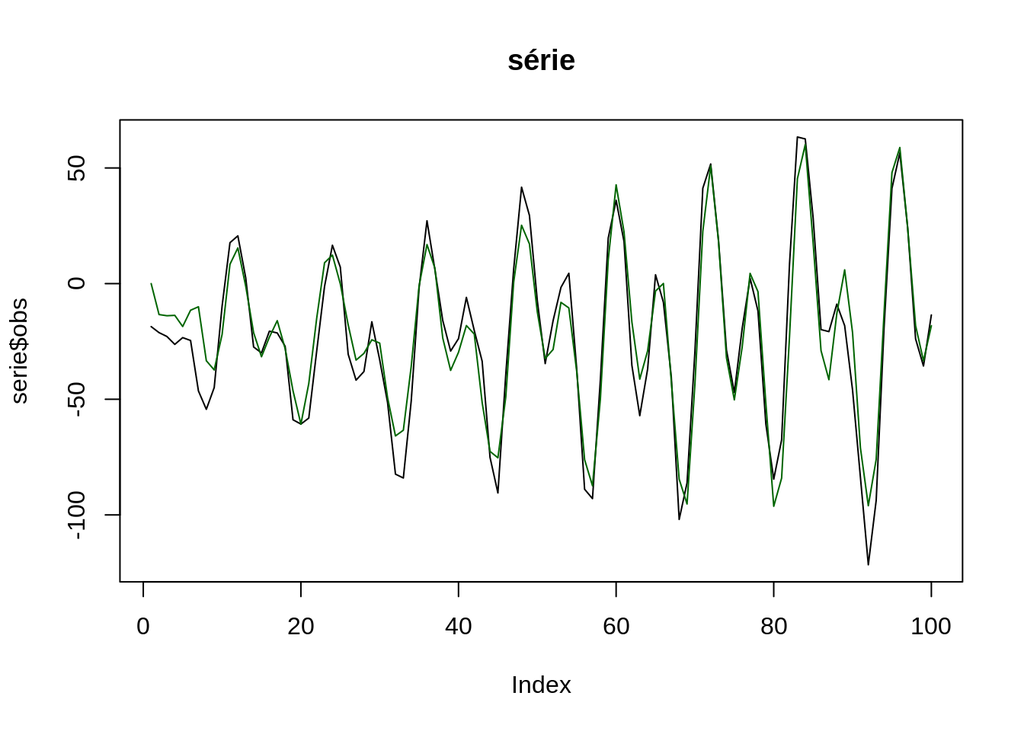

```r
plot(serie$obs,type='l',main = "série")
lines(kalman.desconhecido$f,col="darkgreen")
```

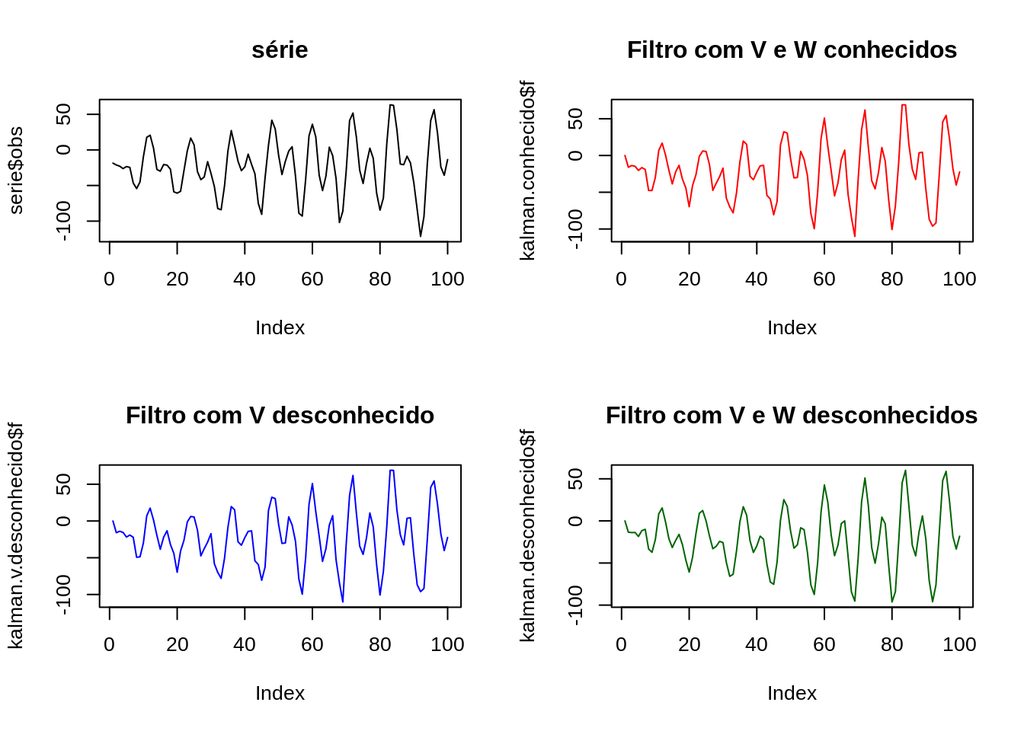

```r
par(mfrow=c(2,2))
plot(serie$obs,type='l',main = "série")
plot(kalman.conhecido$f,col="red",type='l',main="Filtro com V e W conhecidos")
plot(kalman.v.desconhecido$f,col="blue",type='l',main="Filtro com V desconhecido")
plot(kalman.desconhecido$f,col="darkgreen",type='l',main="Filtro com V e W desconhecidos")
```

```r
#TUDO CONHECIDO
kalman.conhecido$acc
```

```
## $MAE
## [1] 170,1052
##
## $MSE
## [1] 2238,543
##
## $MAPE
## [1] -3,003348
```

```r
#TUDO CONHECIDO
kalman.v.desconhecido$acc
```

```
## $MAE
## [1] 168,1158
##
## $MSE
## [1] 2192,838
##
## $MAPE
## [1] -3,025989
```

```r
#TUDO CONHECIDO
kalman.desconhecido$acc
```

```
## $MAE
## [1] 193,5204
##
## $MSE
## [1] 2861,36
##
## $MAPE
## [1] -4,132449
```

#### 3 - Intervalo de credibilidade

```r
hpd.dlm = function(kalman, conf = .95 ,qtd.amostra = 1000){
  rodadas = length(kalman$f)

  f.aux = matrix(NA,nrow = 2,ncol = rodadas)
  m.inf = matrix(NA,nrow = nrow(kalman$C[[1]]),ncol = rodadas)
  m.sup = matrix(NA,nrow = nrow(kalman$C[[1]]),ncol = rodadas)

  if(is.null(kalman$nt)){
    quant_sup = qnorm(1-(1-conf)/2)
    quant_inf = qnorm((1-conf)/2)
  }else{
    quant_sup = qt(1-(1-conf)/2,kalman$nt)
    quant_inf = qt((1-conf)/2,kalman$nt)
  }

  f.aux[1,] = kalman$f + quant_sup * sqrt(kalman$Q)
  f.aux[2,] = kalman$f - quant_sup * sqrt(kalman$Q)


  err = do.call(rbind.data.frame,
                lapply(kalman$C,
                       function(x) quant_sup*sqrt(diag(x)))) %>% t()
  rownames(err) = NULL

  m.inf = kalman$Tt - err
  m.sup = kalman$Tt + err

  return(list(m.inf = m.inf,
              m.sup = m.sup,
              f.aux = f.aux))
}
```

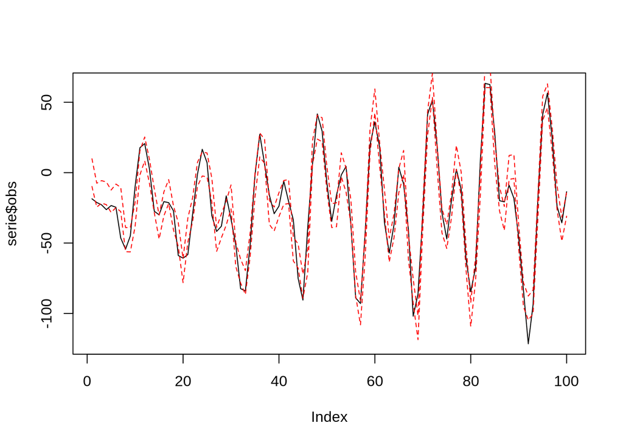

```r
hpd = hpd.dlm(kalman.conhecido)

plot(serie$obs,type = 'l')
lines(hpd$f.aux[1,],lty=2,col="red")
lines(hpd$f.aux[2,],lty=2,col="red")
```

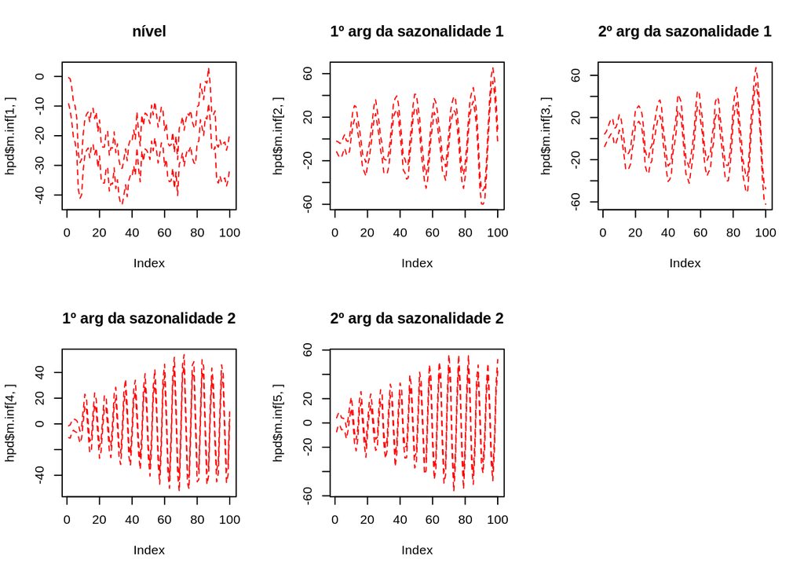

```r
par(mfrow = c(2, 3))

#
plot(hpd$m.inf[1,],type = 'l',lty=2,col="red",ylim = c(min(hpd$m.inf[1,]),
                                                       max(hpd$m.sup[1,])),
     main = "nível")
lines(hpd$m.sup[1,],lty=2,col="red")

#
plot(hpd$m.inf[2,],type = 'l',lty=2,col="red",ylim = c(min(hpd$m.inf[2,]),
                                                       max(hpd$m.sup[2,])),
     main = "1º arg da sazonalidade 1")
lines(hpd$m.sup[2,],lty=2,col="red")

#
plot(hpd$m.inf[3,],type = 'l',lty=2,col="red",ylim = c(min(hpd$m.inf[3,]),
                                                       max(hpd$m.sup[3,])),
     main = "2º arg da sazonalidade 1")
lines(hpd$m.sup[3,],lty=2,col="red")

#
plot(hpd$m.inf[4,],type = 'l',lty=2,col="red",ylim = c(min(hpd$m.inf[4,]),
                                                       max(hpd$m.sup[4,])),
     main = "1º arg da sazonalidade 2")
lines(hpd$m.sup[4,],lty=2,col="red")

#
plot(hpd$m.inf[5,],type = 'l',lty=2,col="red",ylim = c(min(hpd$m.inf[5,]),
                                                       max(hpd$m.sup[5,])),
     main = "2º arg da sazonalidade 2")
lines(hpd$m.sup[5,],lty=2,col="red")
```

### 8) Forward filtering backward sampling (FFBS)

O FFBS é apenas um passo de Filtragem e suavização de um passo do Gibs Sampling, comumente o FFBS é utilizado para o caso em que $Vt$ e $Wt$ são deconhecidos, porém, também é possivel utilizar até mesmo quando estes são conhecidos.

#### 1. Modelo polinomial de primeira ordem

##### 1 - Gerando a série

```r
Ft = 1

Gt = 1
```

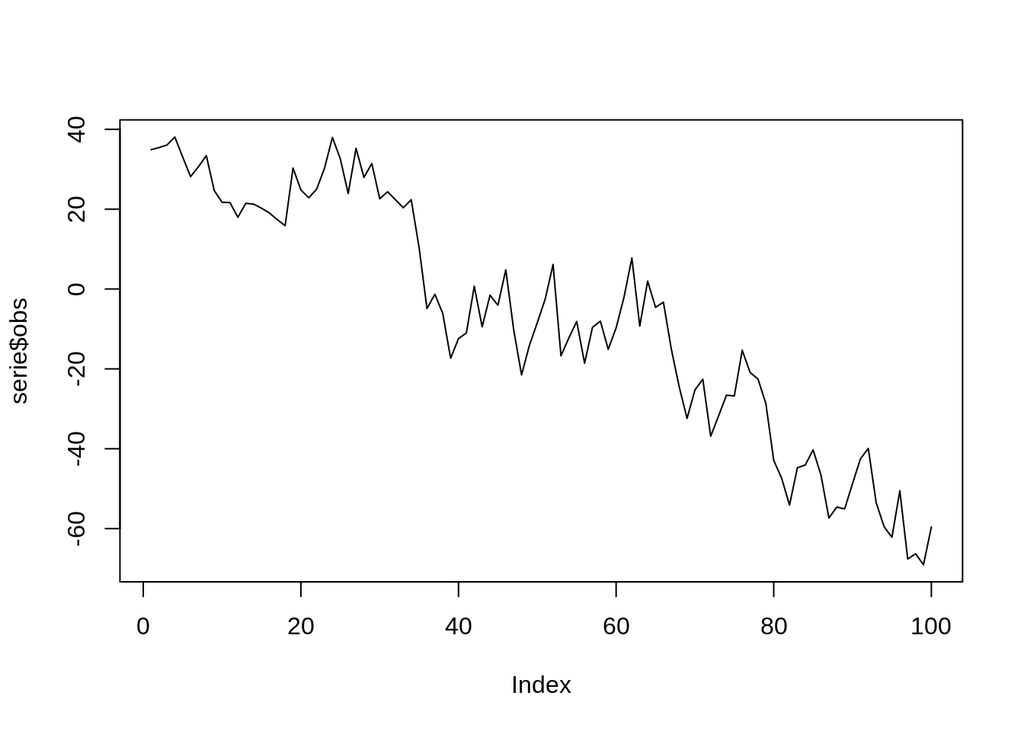

```r
serie = gera_dlm(Vt = 20, Wt = 20, Ft = 1,Gt = 1)

plot(serie$obs,type = 'l')
```

##### 2 - FFBS

$$\Psi_1 = V^{-1} \mbox{~} Ga(\alpha_1,\beta_1)$$
$$\Psi_2 = W^{-1} \mbox{~} Ga(\alpha_2,\beta_2)$$
Posteriori:
$$p(\theta_{0:T},\Psi_1,\Psi_2|y_T) \propto \prod_{i = 1}^{T} L(\theta_t,\Psi_1,\Psi_2,y_t).p(\Psi_1).p(\Psi_2) \prod_{t = 1}^{T} p(\theta_t|\theta_{t-1},\Psi_2).p(\theta_0)$$

$$p(\Psi_1|tudo) \propto p(\Psi_1).\prod_{t = 1}^{T}L(\theta_t,\Psi_1;y_t)$$
$$...$$

$$\Psi_1|tudo \mbox{~} Ga(\alpha_1+\frac{T}{2},\beta_1+\frac{1}{2}\sum_{t=1}^T(y_t-\theta_t)^2)$$

$$\Psi_2|tudo \mbox{~} Ga(\alpha_2\frac{T}{2},\beta_2+\frac{1}{2}\sum_{t=1}^T(\theta_t-\theta_{t-1})^2)$$